# **phenomis**: Postprocessing and univariate statistical analysis of omics data

Etienne A. Thevenot

27 septembre 2026

#### Package

phenomis 1.15.6

# 1 Introduction

## 1.1 Context

Analysis of a molecular phenotyping (e.g. metabolomics) data sets (i.e. samples times variables table of peak or bucket intensities generated by preprocessing tools such as XCMS) is aimed at **mining the data** (e.g. detecting trends and outliers) and selecting features of predictive value (**biomarker discovery**). It comprises multiple steps including:

- **Post-processing** (quality control, normalization and/or transformation of intensities)
- **Statistical analysis** (univariate hypothesis testing, multivariate modeling, feature selection)
- **Annotation** (physico-chemical properties, biological pathways)

The **`phenomis`** package focuses on the two first steps, and can be combined with other packages for multivariate modeling, feature selection and annotation, such as the [**`ropls`**](https://doi.org/10.18129/B9.bioc.ropls) and [**`biosigner`**](https://doi.org/10.18129/B9.bioc.biosigner) and [**`biodb`**](https://www.bioconductor.org/packages/biodb/) Bioconductor packages. As an example, the tutorial below reproduces the whole workflow described in the `sacurine` study (Thévenot et al. 2015). The `phenomis` package has also been used to post-processed the preclinical, proteomics and metabolomics data from the ProMetIS study (Imbert et al. 2021). Proteomics and metabolomics data from this study are provided as a second dataset, named `prometis`. Examples of statistical analyses of this dataset are provided in the “Working with multi-omics datasets” section.

## 1.2 Methods

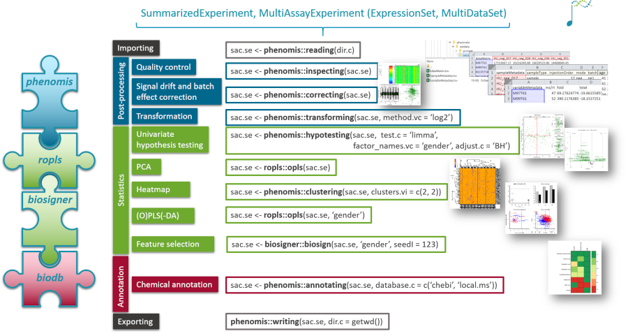

Methods from the **phenomis**, **ropls**, and **biosigner** packages for the analysis of omics datasets; specific parameter values used for the **sacurine** metabolomics dataset described in the ‘Hands-on’ part below are provided as examples.

## 1.3 Formats

### 1.3.1 Managing data and metadata: the `SummarizedExperiment` and `MultiAssayExperiment` formats

The standard `SummarizedExperiment` and `MultiAssayExperiment` Bioconductor formats for single and multi-omics datasets are used by the `phenomis` methods. The methods return updated `SummarizedExperiment` and `MultiAssayExperiment` objects with either modified assay matrices (e.g. when using the `transforming` method) or enriched `rowData` and `colData` with new columns (e.g. fold changes and *p*-values when using the `hypotesting` method).

Note: the phenomis methods for `ExpressionSet` and `MultiDataSet` are deprecated and have been removed from the package.

### 1.3.2 Importing from/exporting to tabular files

Input (i.e. preprocessed) data consists of a ‘variable times sample’ matrix of intensities (**dataMatrix** numeric matrix), in addition to sample and variable metadata (**sampleMetadata** and **variableMetadata** data frames). Importantly, the row names from the dataMatrix must be identical to the row names from the vaiableMetadata (feature names), and the column names from the dataMatrix must be identical to the row names from sampleMetadata (sample names).

Note that 3 sample metadata columns should be specified when working with the `correcting` method, namely:

- **sampleType** (character): the following types are handled by the algorithms:
  - **sample**: biological sample of interest
  - **blank**: e.g. solvent only in Liquid Chromatography coupled to Mass Spectrometry
  - **pool**: quality control sample generated by pooling an equal volume of each of the sample of interest from the whole study (i.e. from all batches)
  - **poolN**: (where *N* is an integer; e.g. pool2, pool4, …): diluted quality control sample: *N* indicates the dilution factor
- **injectionOrder** (integer): order of the sample injection (e.g. in the LC-MS instrument)
- **batch** (character): name of each batch

## 1.4 Text and graphical outputs

Text and graphics can be handled with the *phenomis* methods by setting the two arguments:

- **`report.c`**: if set to ‘interactive’ [default], messages are displayed interactively; if set to a character corresponding the a filename (with the ‘.txt’ extension), messages are diverted to this file by using the *sink* function internally (the same file can be appended by successive methods); if set to ‘none’, messages are suppressed
- **`figure.c`**: if set to ‘interactive’ [default], graphics are displayed interactively; if set to a character corresponding the a filename (with the ‘.pdf’ extension), a pdf file with the plot is generated instead; if set to ‘none’, graphics are suppressed

# 2 Hands-on

## 2.1 The **sacurine** cohort study

As an example, we will use the **`phenomis`** package to study the **sacurine** human cohort. The study is aimed at characterizing the physiological variations of the human urine metabolome with age, body mass index (BMI), and gender (Thévenot et al. 2015). Urine samples from 184 volunteers were analyzed by reversed-phase (C18) ultrahigh performance liquid chromatography (UPLC) coupled to high-resolution mass spectrometry (LTQ-Orbitrap). Raw data are publicly available on the MetaboLights repository (MTBLS404).

This vignette describes the statistical analysis of the data set from the negative ionization mode (113 identified metabolites at MSI levels 1 or 2):

- **`correcting`**: Correction of the signal drift by local regression (loess) modeling of the intensity trend in pool samples (Dunn et al. 2011); Adjustment of oﬀset diﬀerences between the two analytical batches by using the average of the pool intensities in each batch (Kloet et al. 2009)
- Variable quality control by discarding features with a coefficient of variation above 30% in *pool* samples
- Normalization by the sample osmolality
- **`transforming`**: log2 transformation
- **`inspecting`**: Computing metrics to filter out outlier samples according to the Weighted Hotellings’T2 distance (Tenenhaus 1999), the Z-score of one of the intensity distribution deciles (Alonso et al. 2011), and the Z-score of the number of missing values (Alonso et al. 2011). A 0.001 threshold for all p-values results in the HU_096 sample being discarded
- **`hypotesting`**: Univariate hypothesis testing of significant variations with age, BMI, or between genders (Student’s T test with Benjamini Hochberg correction)
- PCA exploration of the data set; [**`ropls`**](https://doi.org/10.18129/B9.bioc.ropls) Bioconductor package (Thévenot et al. 2015)
- **`clustering`**: Hierarchical clustering
- OPLS(-DA) modeling of age, BMI and gender; [**`ropls`**](https://doi.org/10.18129/B9.bioc.ropls) Bioconductor package (Thévenot et al. 2015)
- Selection of the features which significantly contributes to the discrimination between gender with PLS-DA, Random Forest, or Support Vector Machines classifiers; [**`biosigner`**](https://doi.org/10.18129/B9.bioc.biosigner) Bioconductor package (Rinaudo et al. 2016)

A Galaxy version of this analysis is available [W4M00001 ‘Sacurine-statistics’](https://doi.org/10.15454/1.4811121736910142E12) on the [workflow4metabolomics.usegalaxy.fr](https://workflow4metabolomics.usegalaxy.fr/) online infrastructure (Guitton et al. 2017).

## 2.2 **`reading`**: reading the data

The **`reading`** function reads the data sets and builds the `SummarizedExperiment` object. Additional information on how to build and handle `SummarizedExperiment` objects (as well as `MultiAssayExperiment`, `ExpressionSet`, and `MultiDataSet`) are provided in the **Appendix**.

```r
library(phenomis)
sacurine.se <- reading(system.file("extdata/sacurine", package = "phenomis"))
```

```
## class: SummarizedExperiment
## dim: 113 210
## metadata(3): experimentData annotation protocolData
## assays(1): exprs
## rownames(113): (2-methoxyethoxy)propanoic acid isomer
##   (gamma)Glu-Leu/Ile ... Valerylglycine isomer 2 Xanthosine
## rowData names(10): database_identifier chemical_formula ...
##   retention_time reliability
## colnames(210): QC1_001 HU_neg_017 ... HU_neg_146_b2 QC1_012_b2
## colData names(10): subset full ... bmi gender
```

## 2.3 **`inspecting`**: looking at the data

The `inspecting` method provides a numerical and graphical overview of the data. Furthermore, it computes quality metrics which may subsequently be used to filter out some samples or variables.

- Graphical overview. The data matrix is visualized with a color gradient (top right) and the score plot of the Principal Component Analysis is shown for the two first components (bottom right). The black ellipse corresponds to the area of 95% of the samples, as computed with the Hotelling test. For each sample the mean of variable intensities is shown as a function of the injection order to detect any signal drift and/or batch correction (bottom left). Note that for this coloring to be displayed, the **sampleType**, **injectionOrder** and **batch** columns should be provided in the `colData` of (each of) the dataset(s). Finally, some metrics are computed regarding the proportion of NAs, 0 values, intensity quantiles, and proportion of features with a coefficient of variation in pool intensities < 30%.
- Quality metrics (as additional column in the metadata):
  - **samples** (added in the `colData`):
    - hotel_pval: *p*-value from the Hotelling’s T2 test in the first plane of the PC components
    - miss_pval: p-value associated to the z-score of the proportion of missing values (Alonso et al. 2011)
    - deci_pval: p-value associated to the z-score of intensity deciles (Alonso et al. 2011)

      For each test, low *p*-values highlight samples with extreme behavior.
  - **features** (included in the `rowData`)
    - When the type of samples is available (ie the **sampleType** column is included in the input `colData` from the individual datasets), variable metrics are computed: sample, pool, and blank mean, sd and coefficient of variation (if the corresponding types are present in the ‘sampleType’ column), as well as ‘blank’ mean / ‘sample’ mean, and ‘pool’ CV / ‘sample’ CV ratio
    - If pool dilutions have been used and are indicated in the ‘sampleType’ column as poolN where N is an integer indicating the dilution factor (eg pool2 for a two-fold dilution of the pool; note that the non-diluted pool remains indicated as ‘pool’) the Pearson correlation (and corresponding p-value) between the intensity and the dilution factor is computed for each variable

```r
sacurine.se <- inspecting(sacurine.se, report.c = "none")
```

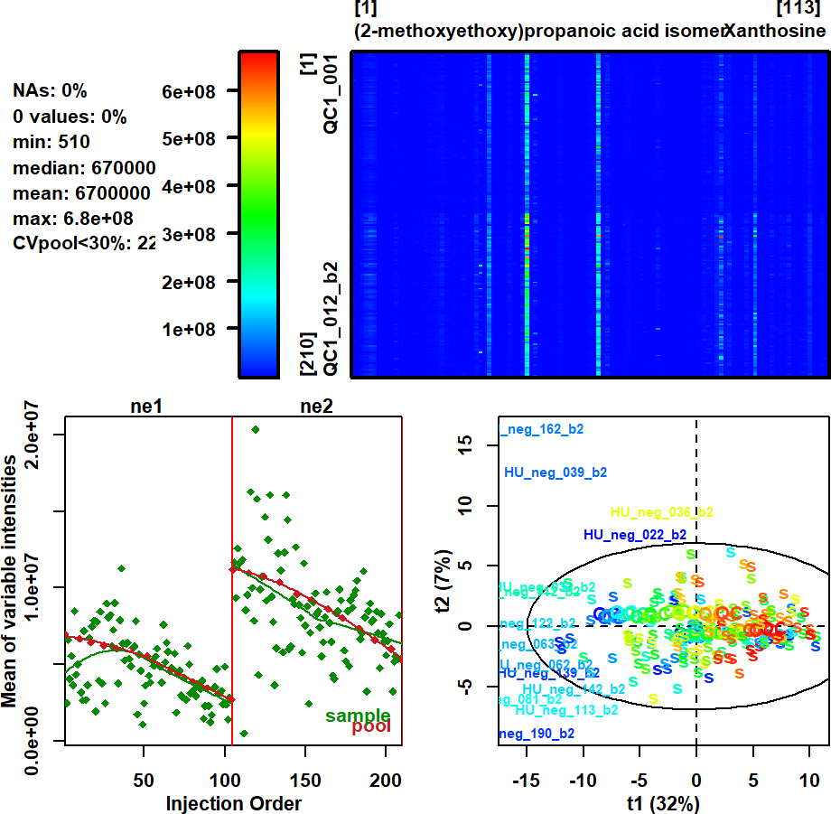

The `filtering` method may be used to discard samples and/or features with a high proportion of missing values and/or a variance of 0. When filtering the features, sample class may be specified (as the name a column from the sample metadata): in this case, features will be kept when:

1. the proportion of missing values is below the threshold in at least one class
2. the variance is above 0 in both classes

## 2.4 Post-processing

### 2.4.1 **`correcting`**: Correcting signal drift and batch effect

For each feature, the signal drift and the batch effect are corrected by using a normalization strategy which relies on the measurements of a pooled (or QC) sample injected periodically: for each variable, a regression model is fitted to the values of the pool and subsequently used to adjust the intensities of the samples of interest (Kloet et al. 2009; Dunn et al. 2011). The sample metadata of each datasets (e.g. `colData` Data Frames) must contain 3 columns:

1. **sampleType** (character): either ‘sample’, ‘blank’, or ‘pool’
2. **injectionOrder** (integer): order of injection in the instrument
3. **batch** (character): batch name

```r
sacurine.se <- correcting(sacurine.se,
    reference.vc = "pool",
    report.c = "none"
)
```

```
## Correction method: loess
```

```
## Reference observations: pool
```

```
## Processing batch:
```

```
## ne1
```

```
## ne2
```

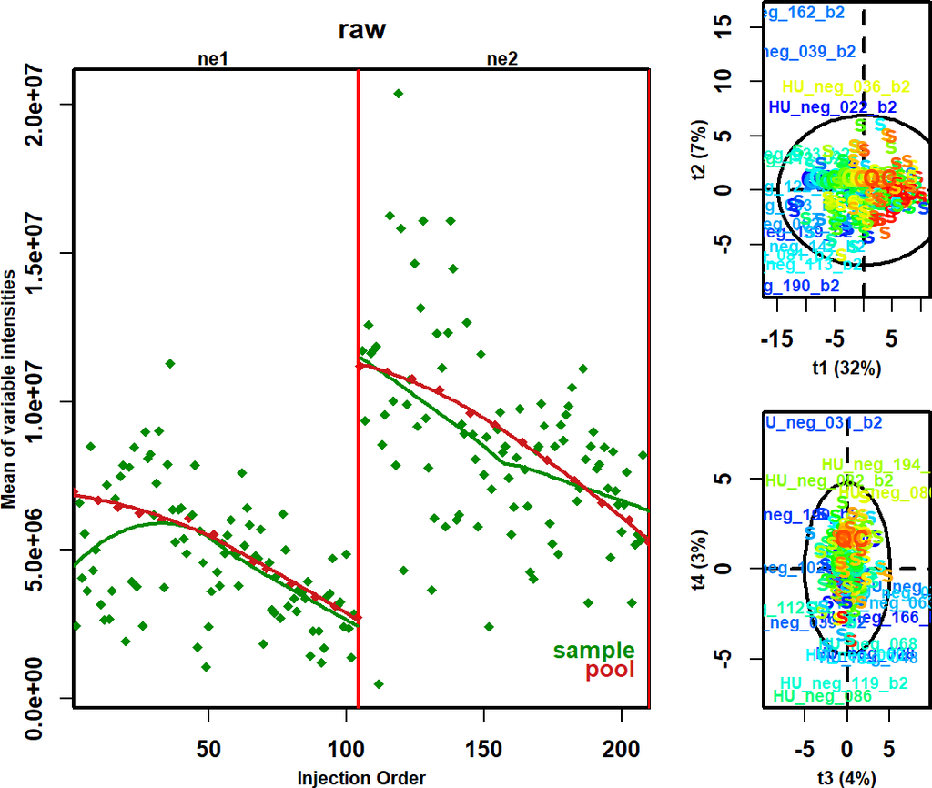

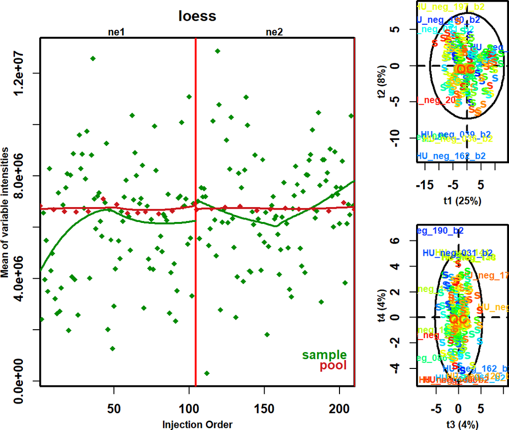

### 2.4.2 Variable filtering

- using **`inspecting`** to compute the ‘pool_CV’ metric

```r
sacurine.se <- inspecting(sacurine.se,
    figure.c = "none", report.c = "none"
)
```

- discarding features with ‘pool_CV’ > 0.3

```r
sacurine.se <- sacurine.se[rowData(sacurine.se)[, "pool_CV"] <= 0.3, ]
```

- discarding the ‘pool’ observations

```r
sacurine.se <- sacurine.se[, colData(sacurine.se)[, "sampleType"] != "pool"]
print(sacurine.se)
```

```
## class: SummarizedExperiment
## dim: 110 184
## metadata(3): experimentData annotation protocolData
## assays(1): exprs
## rownames(110): (2-methoxyethoxy)propanoic acid isomer
##   (gamma)Glu-Leu/Ile ... Valerylglycine isomer 2 Xanthosine
## rowData names(14): database_identifier chemical_formula ... poolDil_cor
##   poolDil_pval
## colnames(184): HU_neg_017 HU_neg_018 ... HU_neg_106_b2 HU_neg_146_b2
## colData names(15): subset full ... miss_pval deci_pval
```

### 2.4.3 Normalization

The normalization of each sample by its ‘osmolality’ value does not require any extra method and relies on the classical methods from the `SummarizedExperiment` package.

```r
assay(sacurine.se) <- sweep(
    assay(sacurine.se),
    2,
    colData(sacurine.se)[, "osmolality"],
    "/"
)
```

Note that a `normalizing` method is available in the `phenomis` package to perform Probabilistic Quotient Normalization (Dieterle et al. 2006).

### 2.4.4 **`transforming`**: transforming the data intensities

```r
sacurine.se <- transforming(sacurine.se, method.vc = "log2")
```

```
## 'log2' transformation
```

### 2.4.5 Sample filtering

```r
sacurine.se <- inspecting(sacurine.se, figure.c = "none", report.c = "none")
sacurine.se <- sacurine.se[, colData(sacurine.se)[, "hotel_pval"] >= 0.001 &
    colData(sacurine.se)[, "miss_pval"] >= 0.001 &
    colData(sacurine.se)[, "deci_pval"] >= 0.001]
```

Final visual check of the data before performing the statistics:

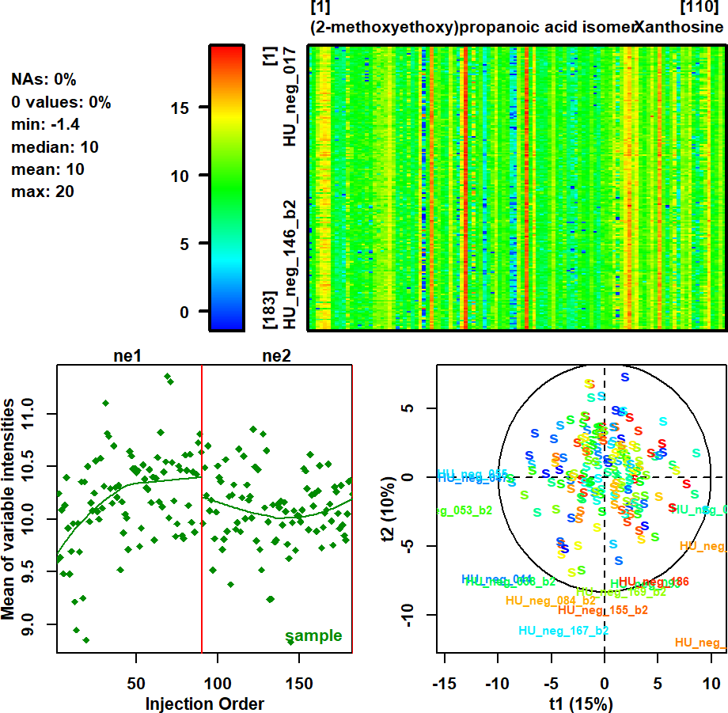

```r
inspecting(sacurine.se, report.c = "none")
```

## 2.5 **`hypotesting`**: univariate hypothesis testing

The `hypotesting` method is a wrapper of the main R functions for hypothesis testing and corrections for multiple testing. The list of available tests include two sample tests (t-test and Wilcoxon rank test, but also the limma test), analysis of variance (for one and two factors) and Kruskal-Wallis rank test, and correlation tests (by using either the pearson or the spearman correlation).

Note that the `transforming` method needs to be applied before `hypotesting` as the transformation impacts the computation of the fold change which will be returned in the object and displayed as the abscissa of the Volcano Plot:

- When no transformation was selected (`method.vc` argument set to ‘none’), the fold change is computed as the ratio between the means (or medians for non-parametric tests) of the two groups:

$$\frac{\frac{1}{n_{B}}\sum_{j\in B}y_j}{\frac{1}{n_{A}}\sum_{i\in A}y_i}$$

where A and B are the levels of the factor in the alphabetical order, unless a specific order is specified with the `factor_levels.ls` argument.

- When a log transformation was selected (either “log2” or “log10”), the “fold change” is in fact the difference betweens the means (or medians) of the log transformed data:

$$\frac{1}{n_{B}}\sum_{j\in B}log_{a}(y_j) - \frac{1}{n_{A}}\sum_{i\in A}log_{a}(y_i)$$

where $a$ is the base of the logarithm used for the transformation (i.e., either 2 or 10). Although this computation does not give the logarithm of the fold change of the means/medians, it gives the difference between the means/medians used in the test and is classically used in proteomics and RNAseq.

```r
sacurine.se <- hypotesting(sacurine.se,
    test.c = "ttest",
    factor_names.vc = "gender",
    adjust.c = "BH",
    adjust_thresh.n = 0.05,
    report.c = "none"
)
```

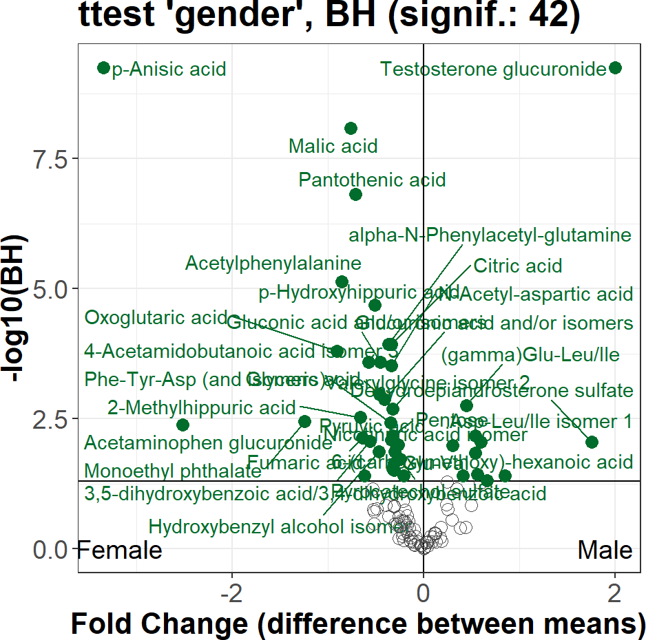

Note that the individual boxplots of the significant variables can be visualized by using the `plot_hypotesting` method with the `display_signif.l` argument set to `TRUE` (default):

```r
plot_hypotesting(sacurine.se,
    test.c = "ttest",
    factor.c = "gender",
    display_signif.l = TRUE,
    report.c = "none"
)
```

The `phenomis` package can be conveniently complemented with other packages for comprehensive statistical analysis and annotation. In the rest of this tutorial, we illustrate how the [**`ropls`**](https://doi.org/10.18129/B9.bioc.ropls), [**`biosigner`**](https://doi.org/10.18129/B9.bioc.biosigner) and [**`biodb`**](https://www.bioconductor.org/packages/biodb/) Bioconductor packages can be included to perform multivariate modeling (Thévenot et al. 2015), feature selection (Rinaudo et al. 2016), and feature annotation (Roger 2022). All these packages support the `SummarizedExperiment` and `MultiAssayExperiment` (but also `ExpressionSet` and `MultiDataSet`), to provide interoperability.

## 2.6 Unsupervised analysis

We first focus on unsupervised methods for multivariate analysis, by performing Principal Component Analysis and hierarchical clustering.

### 2.6.1 Principal component analysis: PCA

PCA can be performed by using the `opls` function from the `ropls` package. It returns an updated object with scores and loadings included as new columns in the metadata. The PCA model is stored in the metadata from the `SummarizedExperiment` and can be accessed with the `getOpls` method:

```r
sacurine.se <- ropls::opls(sacurine.se, info.txt = "none")
```

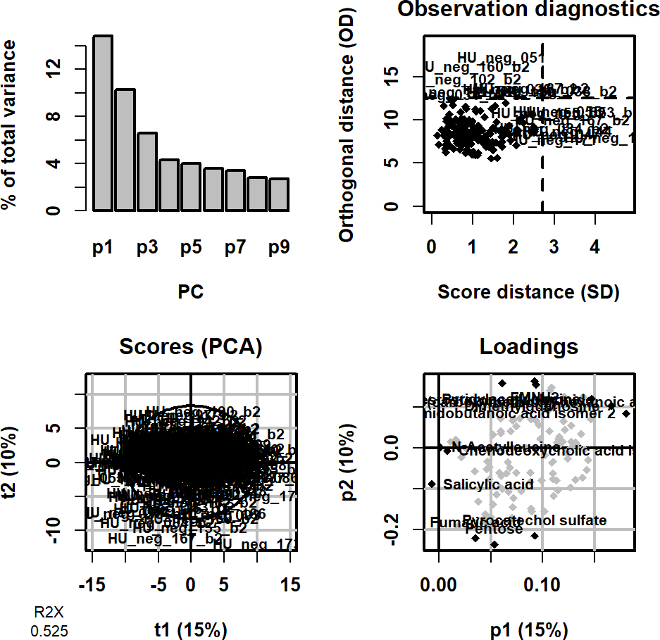

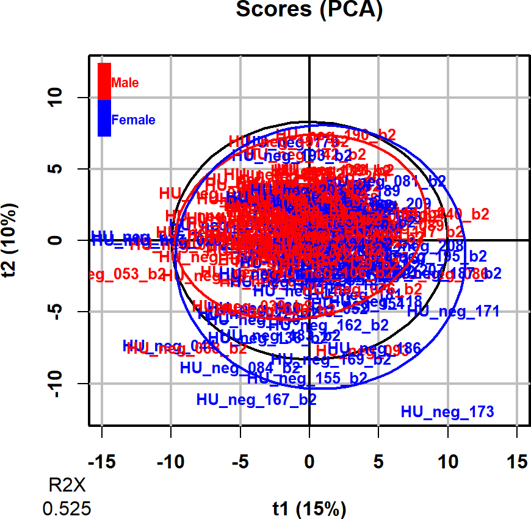

```r
sacurine.pca <- ropls::getOpls(sacurine.se)[["PCA"]]
ropls::plot(sacurine.pca,
    parAsColFcVn = colData(sacurine.se)[, "gender"],
    typeVc = "x-score"
)
```

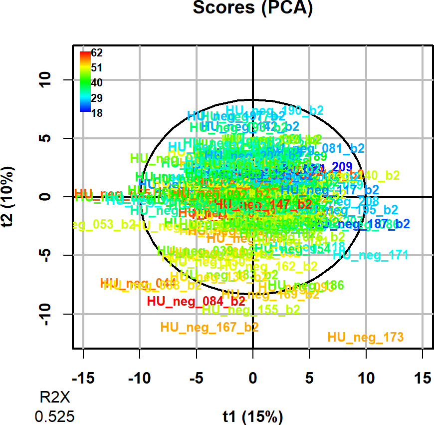

```r
ropls::plot(sacurine.pca,
    parAsColFcVn = colData(sacurine.se)[, "age"],
    typeVc = "x-score"
)
```

### 2.6.2 **`clustering`**: hierarchical clustering

The `clustering` method from the `phenomis` package performs the hierarchical clustering of samples and variables. The default dissimilarity is $1-cor_{pearson}$.

```r
sacurine.se <- clustering(sacurine.se,
    clusters.vi = c(5, 3)
)
```

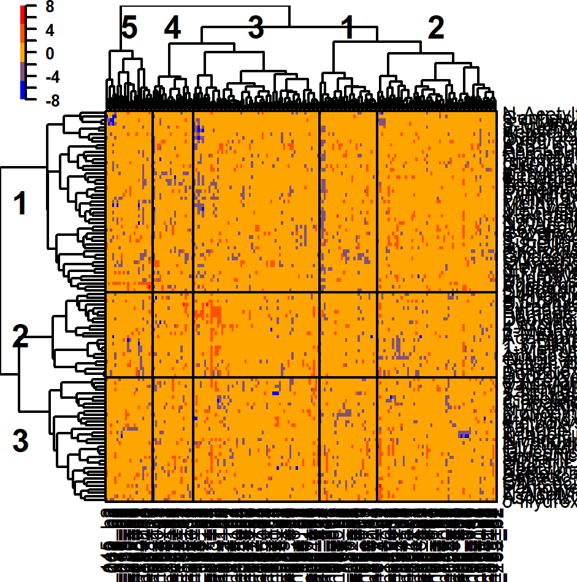

## 2.7 Supervised modeling

We now address the multivariate modeling of the response of interest (either age, bmi, or gender), by using Partial Least Squares modeling and feature selection.

### 2.7.1 Partial Least Squares modeling: (O)PLS(-DA)

Partial Least-Squares (PLS), which is a latent variable regression method based on covariance between the predictors and the response, has been shown to efficiently handle datasets with multi-collinear predictors, as in the case of spectrometry measurements (Wold et al. 2001).

The `opls` function from the `ropls` package can be used to perform Partial Least Squares modeling, by specifying the response to be modeled as the second argument:

```r
sacurine.se <- ropls::opls(sacurine.se, "gender")
```

```
## PLS-DA
## 183 samples x 110 variables and 1 response
## standard scaling of predictors and response(s)
##       R2X(cum) R2Y(cum) Q2(cum) RMSEE pre ort pR2Y  pQ2
## Total    0.273     0.73    0.57 0.261   3   0 0.05 0.05
```

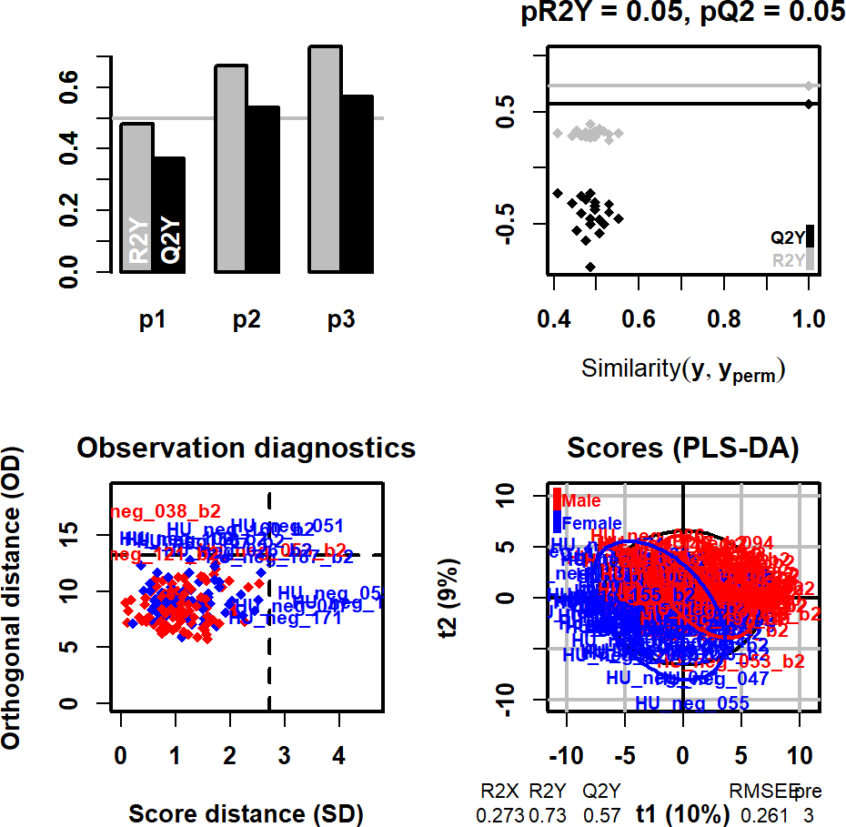

The (O)PLS(-DA) can be obtained from the metadata, e.g. to perform specific plots:

```r
sacurine_gender.plsda <- ropls::getOpls(sacurine.se)[["gender_PLSDA"]]
ropls::plot(sacurine_gender.plsda,
    parAsColFcVn = colData(sacurine.se)[, "gender"],
    typeVc = "x-score"
)
```

[output not shown]

### 2.7.2 Feature selection

The `biosigner` approach is a wrapper method to select the features that significantly contribute to the performance of a binary classifier, namely PLS-DA, random forest, or Support Vector Machine (Rinaudo et al. 2016). We refer the interested reader to the vignette from the `biosigner` package.

```r
sacurine.biosign <- biosigner::biosign(sacurine.se, "gender", bootI = 5)
```

```
## Selecting features for the plsda model
## Selecting features for the randomforest model
## Selecting features for the svm model
## Significant features from 'S' groups:
##                              plsda randomforest svm
## p-Anisic acid                "S"   "S"          "S"
## Testosterone glucuronide     "S"   "S"          "S"
## Oxoglutaric acid             "A"   "S"          "S"
## Pantothenic acid             "A"   "E"          "S"
## Acetylphenylalanine          "B"   "E"          "S"
## Malic acid                   "S"   "E"          "C"
## N2-Acetylaminoadipic acid    "C"   "E"          "S"
## 2-Isopropylmalic acid        "E"   "E"          "S"
## Methoxysalicylic acid isomer "E"   "E"          "S"
## N4-Acetylcytidine            "E"   "E"          "S"
## Pyrroledicarboxylic acid     "E"   "E"          "S"
## Taurine                      "E"   "E"          "S"
## Accuracy:
##      plsda randomforest   svm
## Full 0.867        0.826 0.888
## AS   0.898        0.848 0.910
## S    0.885        0.848 0.941
```

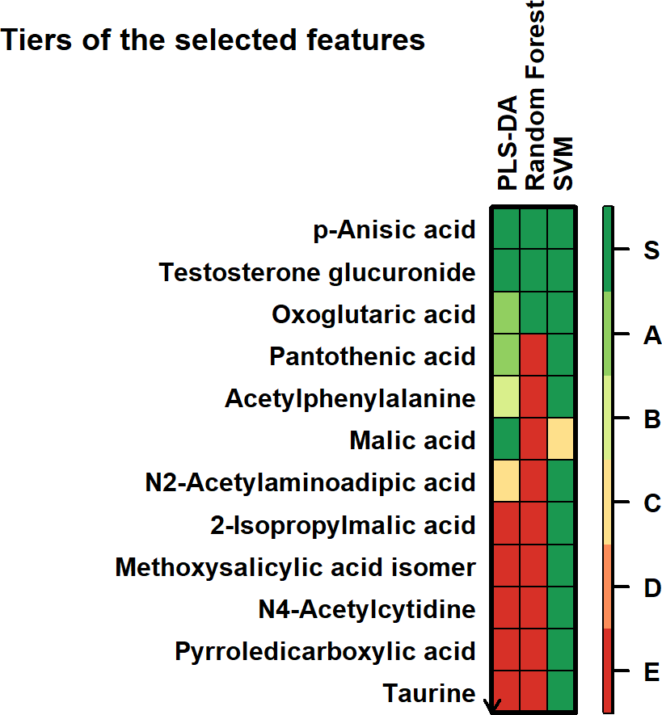

Please note that the `bootI` parameter is set to 5 to speed up the vignette building, but that we advice to keep the default 50 number of bootstraps to obtain more stable signatures.

## 2.8 **`annotating`**: MS annotation

**Note:** The `annotating` method described below is now longer included in the phenomis package because it relies on the biodbChebi package which sometimes encounters building errors on Bioconductor (due to the API connection to CheBI not responding during the unit testing). The `annotating` method can nevertheless be restored by getting the removed file and rebuilding the package as described in the appendix.

This method is based on the [**biodb**](https://www.bioconductor.org/packages/biodb/) package (and its companion [**biodbChebi**](https://www.bioconductor.org/packages/biodbChebi/)), which provides access to standard remote chemical and biological databases (ChEBI, KEGG, HMDB, …), as well as to in-house local database files (CSV, SQLite), with easy retrieval of entries, access to web services, search of compounds by mass and/or name (Roger 2022).

Viewing the parameters from the **`annotating`** method and their default values:

```r
annotating_parameters()
```

Querying chemical annotation from the Chemical Entities of Biological Interest [ChEBI](https://www.ebi.ac.uk/chebi/) database:

1. by using *mz* values:

```r
sacurine.se <- annotating(sacurine.se,
    database.c = "chebi",
    param.ls = list(
        query.type = "mz",
        query.col = "mass_to_charge",
        ms.mode = "neg",
        mz.tol = 10,
        mz.tol.unit = "ppm",
        max.results = 3,
        prefix = "chebiMZ."
    ),
    report.c = "none"
)
knitr::kable(head(rowData(sacurine.se)[, grep(
    "chebiMZ",
    colnames(rowData(sacurine.se))
)]))
```

2. by using ChEBI identifiers:

```r
sacurine.se <- annotating(sacurine.se,
    database.c = "chebi",
    param.ls = list(
        query.type = "chebi.id",
        query.col = "database_identifier",
        prefix = "chebiID."
    )
)
knitr::kable(head(rowData(sacurine.se)[, grep(
    "chebiID",
    colnames(rowData(sacurine.se))
)]))
```

Adding chemical information from a local database:

1. loading a local (example) MS database:

```r
msdbDF <- read.table(system.file("extdata/local_ms_db.tsv", package = "phenomis"),
    header = TRUE,
    sep = "\t",
    stringsAsFactors = FALSE
)
```

2. Querying the local database:

```r
sacurine.se <- annotating(sacurine.se,
    database.c = "local.ms",
    param.ls = list(
        query.type = "mz",
        query.col = "mass_to_charge",
        ms.mode = "neg",
        mz.tol = 5,
        mz.tol.unit = "ppm",
        local.ms.db = msdbDF,
        prefix = "localMS."
    ),
    report.c = "none"
)
knitr::kable(rowData(sacurine.se)[!is.na(rowData(sacurine.se)[, "localMS.accession"]), grep("localMS.", colnames(rowData(sacurine.se)), fixed = TRUE)])
```

## 2.9 **`writing`**: Exporting the results

Finally, the `writing` method can be used to export the `SummarizedExperiment` object in the 3 tabular file format. In case of a `MultiAssayExperiment`, one subfolder containing the 3 files will be created for each dataset.

```r
writing(sacurine.se, dir.c = getwd(), prefix.c = "sacurine")
```

## 2.10 Graphical User Interface

The main features from the `phenomis` package can also be accessed via a graphical user interface in the **Quality Metrics**, **Batch Correction**, **Univariate**, and **Heatmap** modules from the [workflow4metabolomics.usegalaxy.fr](https://workflow4metabolomics.usegalaxy.fr/) online resource for computational metabolomics, based on the Galaxy environment.

## 2.11 Working with multi-omics datasets

The `MultiAssayExperiment` format is useful to handle **multi-omics** datasets (Ramos et al. 2017). The `phenomis` package (as well as the `ropls` and `biosigner` packages) can be used to process the data sets in parallel, such as all methods described before can be directly applied to the `MultiAssayExperiment` object.

In several methods, specific parameters for each dataset can be passed as a vector: for instance, with two datasets, if one wishes to log2 transform the intensities of the first dataset but not the second one, the `method.vc = c("log2", "none")` parameter can be used with the `transforming` method (in contrast, if only one value is provided, it will be used for all datasets).

Here we apply `phenomis` statistical methods to the ProMetIS study , which addresses the molecular phenotyping of knock-out mouse models by combined proteomics and metabolomics analysis (Imbert et al. 2021). The `phenomis` dataset has been selected from the original data (publicly available on GitHub: IFB-ElixirFr/ProMetIS) as follows:

- **liver** data
- **WT** and KO mice for the **LAT** gene (Linker for Activation of T cells) only
- the **proteomics** dataset and the **metabolomics** dataset obtained with the ZIC-pHILIC chromatographic column
- **post-processed** data only
- **100 features** only

The multi-omics dataset is saved as text files and can be loaded with the `reading` function as a `MultiAssayExperiment` (or as a `MultiDataSet` with the `output.c = "set"` argument)

```r
prometis.mae <- reading(system.file("extdata/prometis",
    package = "phenomis"
))
```

```
## Reading the 'metabo' dataset...
```

```
## Reading the 'proteo' dataset...
```

```
## A MultiAssayExperiment object of 2 listed
##  experiments with user-defined names and respective classes.
##  Containing an ExperimentList class object of length 2:
##  [1] metabo: SummarizedExperiment with 100 rows and 28 columns
##  [2] proteo: SummarizedExperiment with 100 rows and 28 columns
## Functionality:
##  experiments() - obtain the ExperimentList instance
##  colData() - the primary/phenotype DataFrame
##  sampleMap() - the sample coordination DataFrame
##  `$`, `[`, `[[` - extract colData columns, subset, or experiment
##  *Format() - convert into a long or wide DataFrame
##  assays() - convert ExperimentList to a SimpleList of matrices
##  exportClass() - save data to flat files
```

Let us have a look at the (common) sample metadata:

```r
head(colData(prometis.mae))
```

```
## DataFrame with 6 rows and 3 columns
##              gene  mouse_id         sex
##       <character> <integer> <character>
## L818f         LAT       818           F
## L819f         LAT       819           F
## L824m         LAT       824           M
## L825m         LAT       825           M
## L826m         LAT       826           M
## L827m         LAT       827           M
```

We apply a log2 transformation:

```r
prometis.mae <- transforming(prometis.mae, method.vc = "log2")
```

```
## Transforming the 'metabo' dataset...
```

```
## 'log2' transformation
```

```
## Transforming the 'proteo' dataset...
```

```
## 'log2' transformation
```

We then explore the datasets:

```r
prometis.mae <- inspecting(prometis.mae, report.c = "none")
```

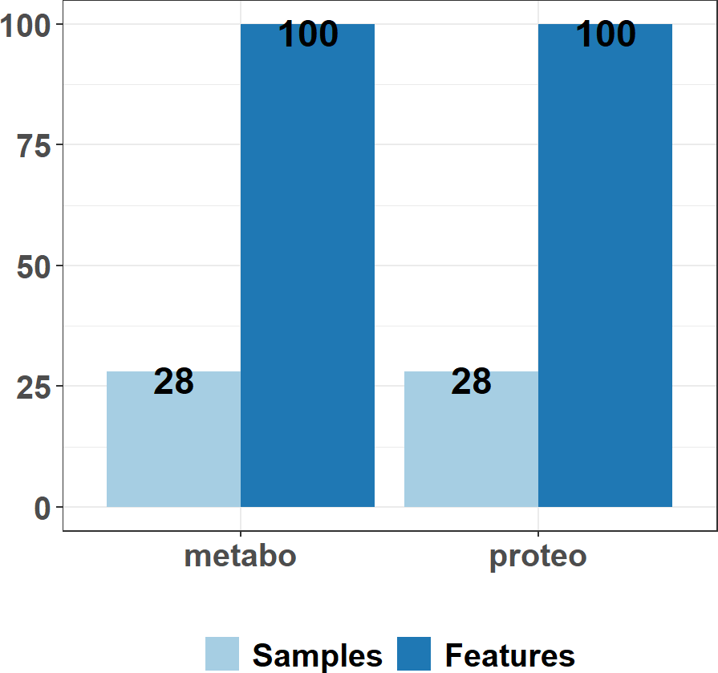

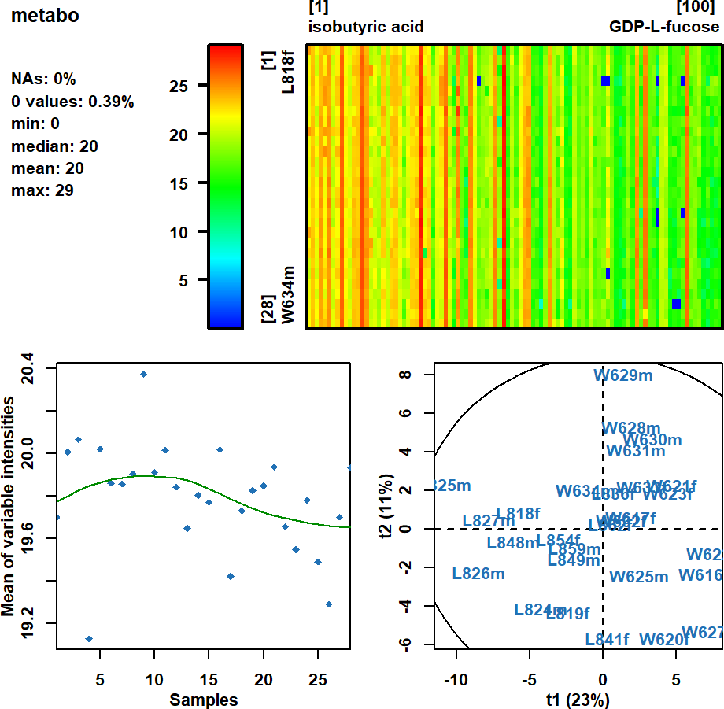

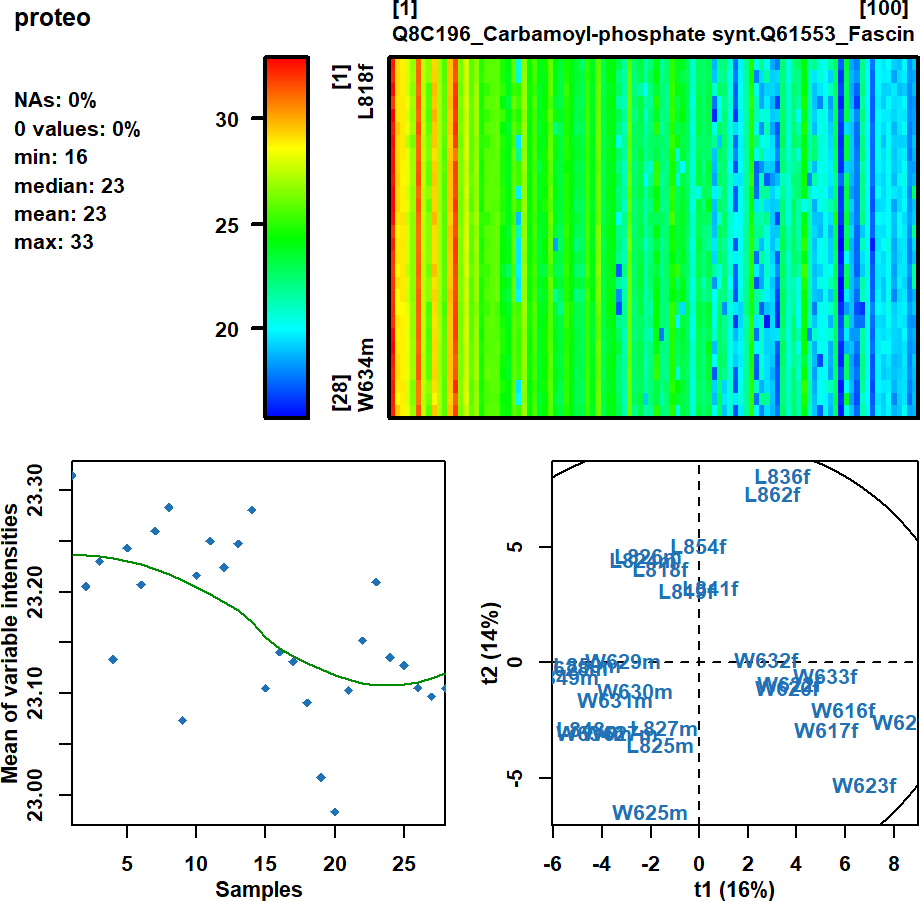

Next, we perform univariate hypothesis testing with the `limma` approach (Ritchie et al. 2015):

```r
prometis.mae <- hypotesting(prometis.mae, "limma", "gene",
    report.c = "none"
)
```

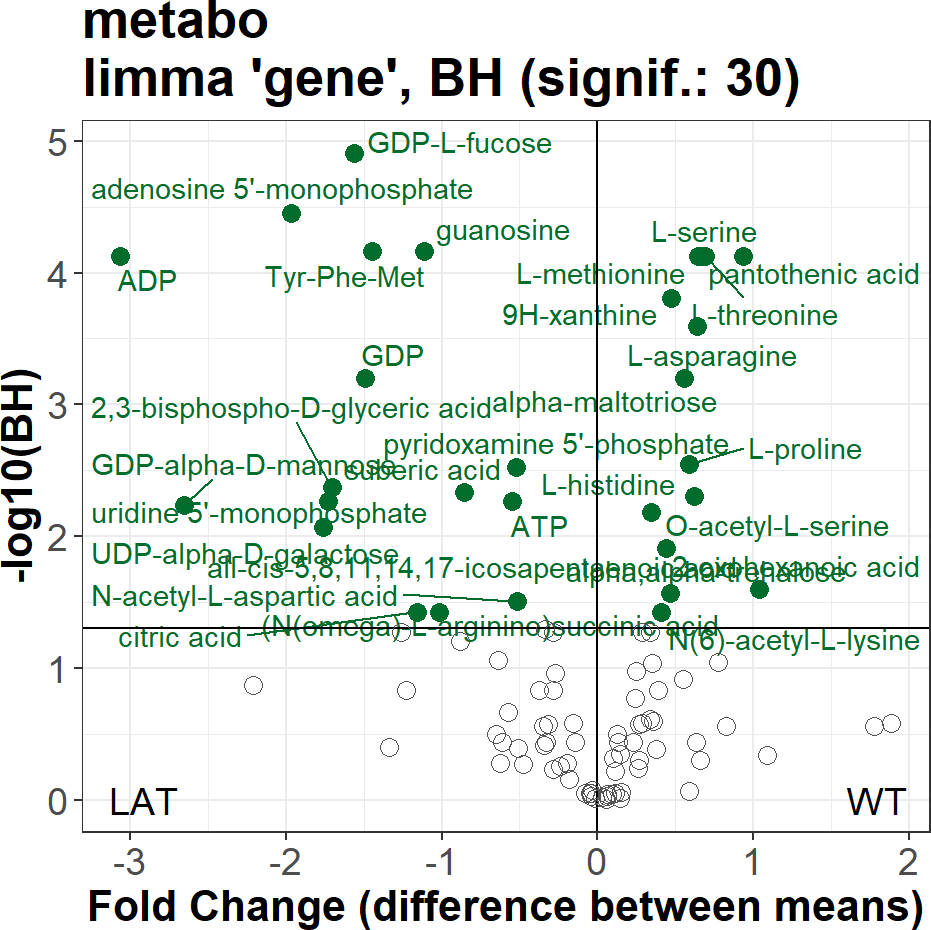

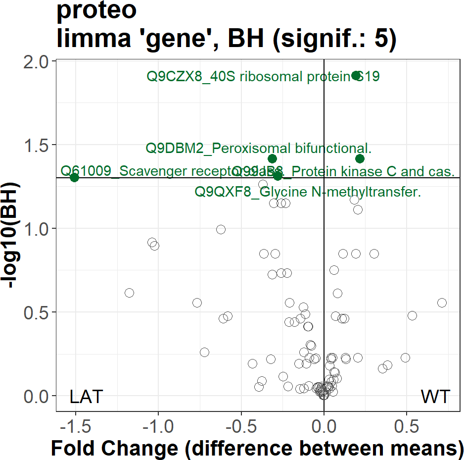

As with single omics studies, the `ropls` and `biosigner` can be directly applied to `MultiAssayExperiment` for multivariate analysis:

```r
prometis.mae <- ropls::opls(prometis.mae, "gene")
```

```
##
##
## Building the model for the 'metabo' dataset:
## PLS-DA
## 28 samples x 100 variables and 1 response
## standard scaling of predictors and response(s)
##       R2X(cum) R2Y(cum) Q2(cum) RMSEE pre ort pR2Y  pQ2
## Total    0.331    0.941   0.859 0.128   2   0 0.05 0.05
```

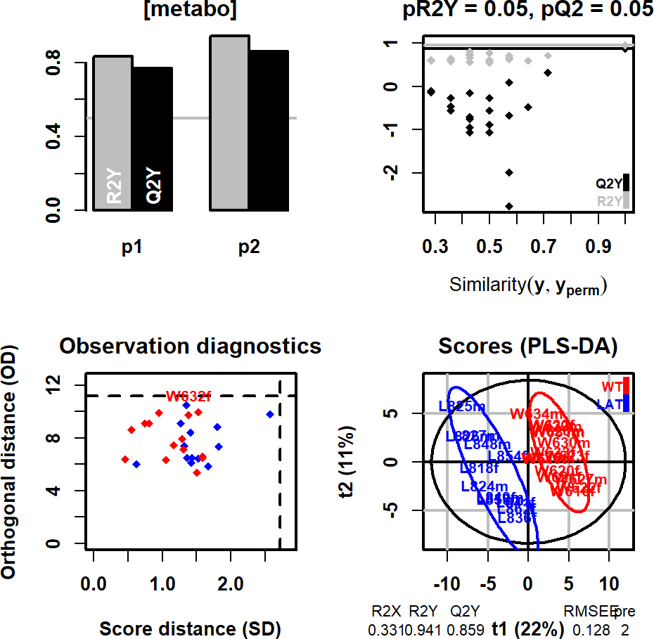

```
##
##
## Building the model for the 'proteo' dataset:
## PLS-DA
## 28 samples x 100 variables and 1 response
## standard scaling of predictors and response(s)
##       R2X(cum) R2Y(cum) Q2(cum) RMSEE pre ort pR2Y  pQ2
## Total    0.137    0.677   0.458 0.294   1   0 0.05 0.05
```

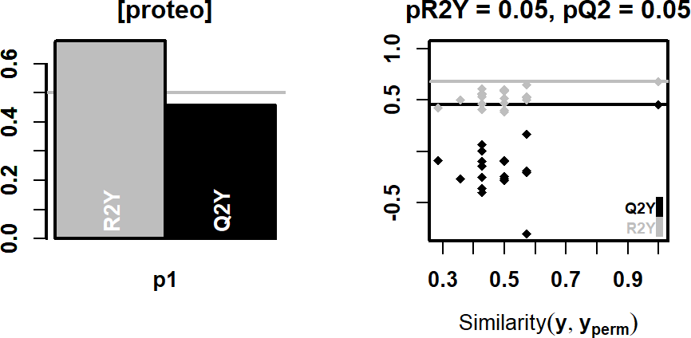

and feature selection:

```r
prometis.mae <- biosigner::biosign(prometis.mae, "gene", bootI = 5)
```

```
##
##
## Selecting the features for the 'metabo' dataset:
## Selecting features for the plsda model
## Selecting features for the randomforest model
## Selecting features for the svm model
## Significant features from 'S' groups:
##                                     plsda randomforest svm
## ADP                                 "B"   "S"          "S"
## GDP-L-fucose                        "S"   "E"          "S"
## 9H-xanthine                         "B"   "S"          "E"
## deoxycholic acid                    "E"   "E"          "S"
## taurocholic acid                    "E"   "E"          "S"
## 3-phenylpropionic acid              "E"   "E"          "S"
## 4-oxo-4-(pyridin-3-yl)butanoic acid "E"   "E"          "S"
## ferulic acid                        "E"   "E"          "S"
## glycocholate                        "E"   "E"          "S"
## UDP-alpha-D-galactose               "E"   "E"          "S"
## Accuracy:
##      plsda randomforest   svm
## Full 0.980        0.949 0.963
## AS   0.912        0.918 0.952
## S    0.830        0.933 0.980
```

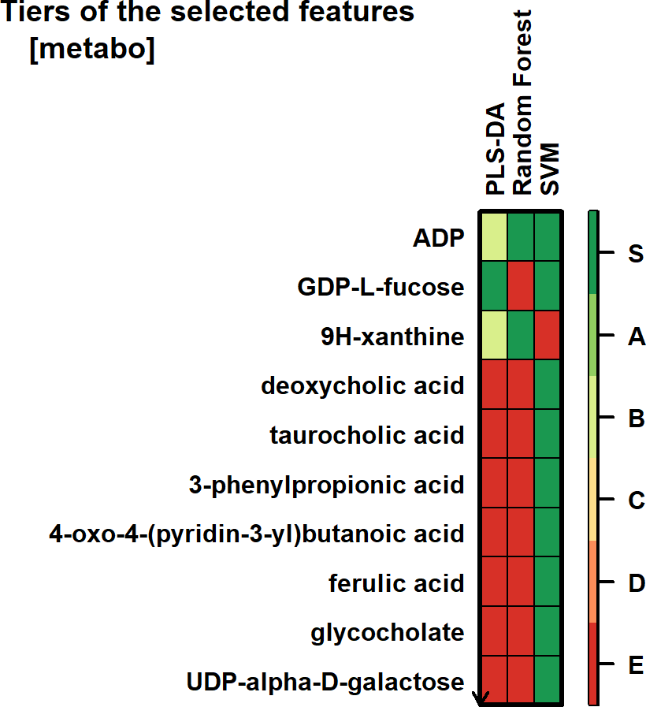

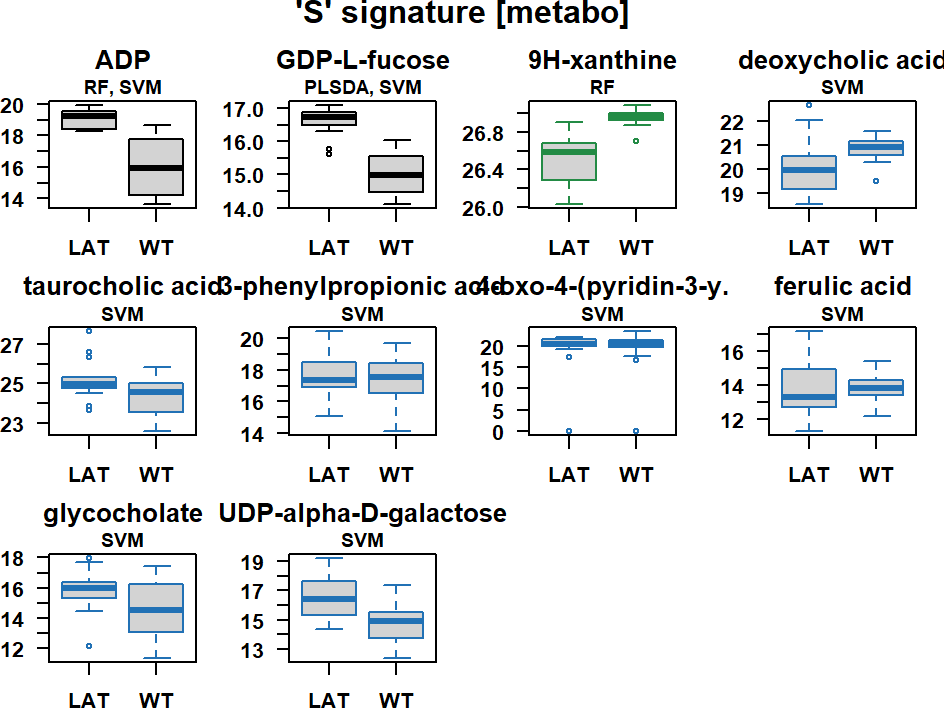

```
##
##
## Selecting the features for the 'proteo' dataset:
## Selecting features for the plsda model
## Selecting features for the randomforest model
## Selecting features for the svm model
## No significant variable found for the selected classifier(s): 'plsda', 'randomforest', 'svm'
```

The final `MultiAssayExperiment` can be exported as text files with:

```r
writing(prometis.mae, dir.c = getwd(), prefix.c = "prometis")
```

# 3 Appendix

## 3.1 Additional examples of application to single and multiple omics data sets

### 3.1.1 NCI60_4arrays data set

We provide an example based on the `NCI60_4arrays` cancer data set from the `omicade4` package (Meng et al. 2014), which has been made available in the `MultiAssayExperiment` format in the `ropls` package. The data consist of gene transcript expression analysis from NCI-60 cell lines by using 4 microarray platforms (Reinhold et al. 2012).

Getting the `NCI60` data set as a `MultiAssayExperiment`:

```r
data(NCI60, package = "ropls")
nci.mae <- NCI60[["mae"]]
```

Let’s focus on the **LE**ukemia and **ME**lanoma cancer types, and the **agilent** and **hgu95** arrays:

```r
library(MultiAssayExperiment)
table(nci.mae$cancer)
```

```
##
## BR CN CO LC LE ME OV PR RE
##  5  6  7  9  6 10  7  2  8
```

```r
nci.mae <- nci.mae[
    ,
    nci.mae$cancer %in% c("LE", "ME"),
    c("agilent", "hgu95")
]
```

We can now e.g. perform clustering on each data set independently:

```r
nci.mae <- clustering(nci.mae)
```

and/or perform hypothesis testing on each data set:

```r
nci.mae <- hypotesting(nci.mae, "limma", "cancer", report.c = "none")
```

as well as all the analyses described above for the `prometis` data set.

## 3.2 Cheat sheets for Bioconductor (multi)omics containers

### 3.2.1 `SummarizedExperiment`

The `SummarizedExperiment` format has been designed by the Bioconductor team to handle (single) omics datasets (Morgan et al. 2022).

An example of `SummarizedExperiment` creation and a summary of useful methods are provided below.

Please refer to [package vignettes](https://bioconductor.org/packages/release/bioc/vignettes/SummarizedExperiment/inst/doc/SummarizedExperiment.html) for a full description of `SummarizedExperiment` objects .

```r
# Preparing the data (matrix) and sample and variable metadata (data frames):
data(sacurine, package = "ropls")
data.mn <- sacurine[["dataMatrix"]] # matrix: samples x variables
samp.df <- sacurine[["sampleMetadata"]] # data frame: samples x sample metadata
feat.df <- sacurine[["variableMetadata"]] # data frame: features x feature metadata

# Creating the SummarizedExperiment (package SummarizedExperiment)
library(SummarizedExperiment)
sac.se <- SummarizedExperiment(
    assays = list(sacurine = t(data.mn)),
    colData = samp.df,
    rowData = feat.df
)
# note that colData and rowData main format is DataFrame, but data frames are accepted when building the object
stopifnot(validObject(sac.se))

# Viewing the SummarizedExperiment
# ropls::view(sac.se)
```

| Methods | Description | Returned class |
| --- | --- | --- |
| **Constructors** |  |  |
| **`SummarizedExperiment`** | Create a SummarizedExperiment object | `SummarizedExperiment` |
| **`makeSummarizedExperimentFromExpressionSet`** |  | `SummarizedExperiment` |
| **Accessors** |  |  |
| **`assayNames`** | Get or set the names of assay() elements | `character` |
| **`assay`** | Get or set the ith (default first) assay element | `matrix` |
| **`assays`** | Get the list of experimental data numeric matrices | `SimpleList` |
| **`rowData`** | Get or set the row data (features) | `DataFrame` |
| **`colData`** | Get or set the column data (samples) | `DataFrame` |
| **`metadata`** | Get or set the experiment data | `list` |
| **`dim`** | Get the dimensions (features of interest x samples) | `integer` |
| **`dimnames`** | Get or set the dimension names | `list` of length 2 character/NULL |
| **`rownames`** | Get the feature names | `character` |
| **`colnames`** | Get the sample names | `character` |
| **Conversion** |  |  |
| **`as(, "SummarizedExperiment")`** | Convert an ExpressionSet to a SummarizedExperiment | `SummarizedExperiment` |

### 3.2.2 `MultiAssayExperiment`

The `MultiAssayExperiment` format has been designed by the Bioconductor team to handle multiomics datasets (Ramos et al. 2017).

An example of `MultiAssayExperiment` creation and a summary of useful methods are provided below. Please refer to [package vignettes](https://bioconductor.org/packages/MultiAssayExperiment/) or to the original publication for a full description of `MultiAssayExperiment` objects (Ramos et al. 2017).

Loading the `NCI60_4arrays` from the `omicade4` package:

```r
data("NCI60_4arrays", package = "omicade4")
```

Creating the `MultiAssayExperiment`:

```r
library(MultiAssayExperiment)
# Building the individual SummarizedExperiment instances
experiment.ls <- list()
sampleMap.ls <- list()
for (set.c in names(NCI60_4arrays)) {
    # Getting the data and metadata
    assay.mn <- as.matrix(NCI60_4arrays[[set.c]])
    coldata.df <- data.frame(
        row.names = colnames(assay.mn),
        .id = colnames(assay.mn),
        stringsAsFactors = FALSE
    ) # the 'cancer' information will be stored in the main colData of the mae, not the individual SummarizedExperiments
    rowdata.df <- data.frame(
        row.names = rownames(assay.mn),
        name = rownames(assay.mn),
        stringsAsFactors = FALSE
    )
    # Building the SummarizedExperiment
    assay.ls <- list(se = assay.mn)
    names(assay.ls) <- set.c
    se <- SummarizedExperiment(
        assays = assay.ls,
        colData = coldata.df,
        rowData = rowdata.df
    )
    experiment.ls[[set.c]] <- se
    sampleMap.ls[[set.c]] <- data.frame(
        primary = colnames(se),
        colname = colnames(se)
    ) # both datasets use identical sample names
}
sampleMap <- listToMap(sampleMap.ls)

# The sample metadata are stored in the colData data frame (both datasets have the same samples)
stopifnot(identical(
    colnames(NCI60_4arrays[[1]]),
    colnames(NCI60_4arrays[[2]])
))
sample_names.vc <- colnames(NCI60_4arrays[[1]])
colData.df <- data.frame(
    row.names = sample_names.vc,
    cancer = substr(sample_names.vc, 1, 2)
)

nci.mae <- MultiAssayExperiment(
    experiments = experiment.ls,
    colData = colData.df,
    sampleMap = sampleMap
)

stopifnot(validObject(nci.mae))
```

| Methods | Description | Returned class |
| --- | --- | --- |
| **Constructors** |  |  |
| **`MultiAssayExperiment`** | Create a MultiAssayExperiment object | `MultiAssayExperiment` |
| **`ExperimentList`** | Create an ExperimentList from a List or list | `ExperimentList` |
| **Accessors** |  |  |
| **`colData`** | Get or set data that describe the patients/biological units | `DataFrame` |
| **`experiments`** | Get or set the list of experimental data objects as original classes | `experimentList` |
| **`assays`** | Get the list of experimental data numeric matrices | `SimpleList` |
| **`assay`** | Get the first experimental data numeric matrix | `matrix`, matrix-like |
| **`sampleMap`** | Get or set the map relating observations to subjects | `DataFrame` |
| **`metadata`** | Get or set additional data descriptions | `list` |
| **`rownames`** | Get row names for all experiments | `CharacterList` |
| **`colnames`** | Get column names for all experiments | `CharacterList` |
| **Subsetting** |  |  |
| **`mae[i, j, k]`** | Get rows, columns, and/or experiments | `MultiAssayExperiment` |
| **`mae[i, ,]`** | i: GRanges, character, integer, logical, List, list | `MultiAssayExperiment` |
| **`mae[,j,]`** | j: character, integer, logical, List, list | `MultiAssayExperiment` |
| **`mae[,,k]`** | k: character, integer, logical | `MultiAssayExperiment` |
| **`mae[[i]]`** | Get or set object of arbitrary class from experiments | (Varies) |
| **`mae[[i]]`** | Character, integer, logical |  |
| **`mae$column`** | Get or set colData column | `vector` (varies) |
| **Management** |  |  |
| **`complete.cases`** | Identify subjects with complete data in all experiments | `vector` (logical) |
| **`duplicated`** | Identify subjects with replicate observations per experiment | `list` of `LogicalLists` |
| **`mergeReplicates`** | Merge replicate observations within each experiment | `MultiAssayExperiment` |
| **`intersectRows`** | Return features that are present for all experiments | `MultiAssayExperiment` |
| **`intersectColumns`** | Return subjects with data available for all experiments | `MultiAssayExperiment` |
| **`prepMultiAssay`** | Troubleshoot common problems when constructing main class | `list` |
| **Reshaping** |  |  |
| **`longFormat`** | Return a long and tidy DataFrame with optional colData columns | `DataFrame` |
| **`wideFormat`** | Create a wide DataFrame, one row per subject | `DataFrame` |
| **Combining** |  |  |
| **`c`** | Concatenate an experiment | `MultiAssayExperiment` |
| **Viewing** |  |  |
| **`upsetSamples`** | Generalized Venn Diagram analog for sample membership | `upset` |
| **Exporting** |  |  |
| **`exportClass`** | Exporting to flat files | `csv` or `tsv` files |